# Practical Machine Learning - Course Project

Alicia Rodriguez

4/18/2017

## Executive Summary

This report describes the building of a prediction model for the multiclass classification problem of deciding if a physical exercise is well performed. The predictors available are the signals coming from several sensors placed in different places of the body of the person performing the physical exercise. Several models are fit using cross-validation and different data preprocessing options, checking the in and out sample errors in each case. The model with the highest accuracy is further explored with respect to resulting confusion matrix and variable importance order.

## Methodology

Let’s load the data and make a first exploratory analysis.

```r
training_original<-read.csv(file="./pml-training.csv", header = TRUE, as.is = TRUE)
testing_quiz_original<-read.csv(file="./pml-testing.csv", header = TRUE, as.is = TRUE)
```

The data set is extensive (thus, not shown here): 19622 samples for the training set, and 20 for the quiz test set, each comprised of 160 variables.

```r
str(training_original)
head(training_original,10)
```

It seems like the data has many columns with multiple NA values. Let’s calculate the percentage of NA values per column:

```r
training_clean<-training_original
training_clean[training_clean==""]<-NA
colSums(is.na(training_clean))*100/length(training_clean[,1])
```

```
##                        I                user_name     raw_timestamp_part_1
##                  0.00000                  0.00000                  0.00000
##     raw_timestamp_part_2           cvtd_timestamp               new_window
##                  0.00000                  0.00000                  0.00000
##               num_window                roll_belt               pitch_belt
##                  0.00000                  0.00000                  0.00000
##                 yaw_belt         total_accel_belt       kurtosis_roll_belt
##                  0.00000                  0.00000                 97.93089
##      kurtosis_picth_belt        kurtosis_yaw_belt       skewness_roll_belt
##                 97.93089                 97.93089                 97.93089
##     skewness_roll_belt.1        skewness_yaw_belt            max_roll_belt
##                 97.93089                 97.93089                 97.93089
##           max_picth_belt             max_yaw_belt            min_roll_belt
##                 97.93089                 97.93089                 97.93089
##           min_pitch_belt             min_yaw_belt      amplitude_roll_belt
##                 97.93089                 97.93089                 97.93089
##     amplitude_pitch_belt       amplitude_yaw_belt     var_total_accel_belt
##                 97.93089                 97.93089                 97.93089
##            avg_roll_belt         stddev_roll_belt            var_roll_belt
##                 97.93089                 97.93089                 97.93089
##           avg_pitch_belt        stddev_pitch_belt           var_pitch_belt
##                 97.93089                 97.93089                 97.93089
##             avg_yaw_belt          stddev_yaw_belt             var_yaw_belt
##                 97.93089                 97.93089                 97.93089
##             gyros_belt_x             gyros_belt_y             gyros_belt_z
##                  0.00000                  0.00000                  0.00000
##             accel_belt_x             accel_belt_y             accel_belt_z
##                  0.00000                  0.00000                  0.00000
##            magnet_belt_x            magnet_belt_y            magnet_belt_z
##                  0.00000                  0.00000                  0.00000
##                 roll_arm                pitch_arm                  yaw_arm
##                  0.00000                  0.00000                  0.00000
##          total_accel_arm            var_accel_arm             avg_roll_arm
##                  0.00000                 97.93089                 97.93089
##          stddev_roll_arm             var_roll_arm            avg_pitch_arm
##                 97.93089                 97.93089                 97.93089
##         stddev_pitch_arm            var_pitch_arm              avg_yaw_arm
##                 97.93089                 97.93089                 97.93089
##           stddev_yaw_arm              var_yaw_arm              gyros_arm_x
##                 97.93089                 97.93089                  0.00000
```

[output cut: 53 more lines]

```
##                 97.93089                  0.00000                 97.93089
##         avg_roll_forearm      stddev_roll_forearm         var_roll_forearm
##                 97.93089                 97.93089                 97.93089
##        avg_pitch_forearm     stddev_pitch_forearm        var_pitch_forearm
##                 97.93089                 97.93089                 97.93089
##          avg_yaw_forearm       stddev_yaw_forearm          var_yaw_forearm
##                 97.93089                 97.93089                 97.93089
##          gyros_forearm_x          gyros_forearm_y          gyros_forearm_z
##                  0.00000                  0.00000                  0.00000
##          accel_forearm_x          accel_forearm_y          accel_forearm_z
##                  0.00000                  0.00000                  0.00000
##         magnet_forearm_x         magnet_forearm_y         magnet_forearm_z
##                  0.00000                  0.00000                  0.00000
##                   classe
##                  0.00000
```

Two cases can be observed: columns with 0% of NA values, and columns with almost 98% of NA values. Therefore, it seems like imputing data is not going to be a good idea here since there are way more NAs than real values, thus we proceed to delete the columns with NA values. Besides, some other variables of no interest will be deleted such us $I$, $user\_name$, and those related to timestamps and temporal windows. Lastly, the column $classe$ (the output to predict) will be factored.

```r
valid_columns<-colSums(is.na(training_clean))==0
training_clean<-training_clean[,valid_columns]
training_clean<-training_clean[,-which(names(training_clean) %in% c("I","user_name","raw_timestamp_part_1","raw_timestamp_part_2","cvtd_timestamp","new_window","num_window"))]
training_clean$classe<-factor(training_clean$classe)
```

Now there are 19622 samples, with 52 predictors each, and the dependent variable to predict, $classe$, which is a factor variable now. Since the number of variables is so high, showing scatter plots is pretty difficult. Just for illustrative reasons, let’s plot only some variables.

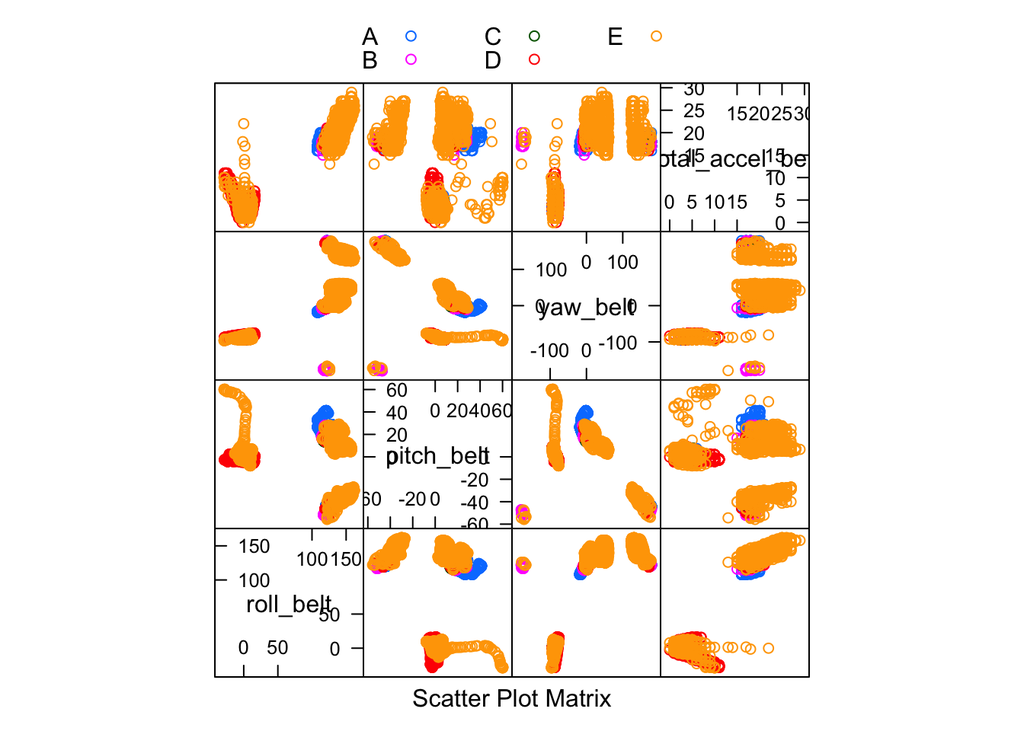

```r
featurePlot(x = training_clean[,1:4],
             y = training_clean$classe,
             plot = "pairs",
             ## Add a key at the top
             auto.key = list(columns = 3))
```

Clear groups can be spotted at each plot, but they seem very mixed, so it’s difficult to extract any hypothesis on the model. It may be more obvious correlations with other variables not represented here, but since the nunber is so high, we will not represent the whole set.

Next, let’s pre-process the data. First, let’s look at any possible near-zero-variance variable in order to delete it, so it does not cause any problem when resampling during cross-validation.

```r
nzv <- nearZeroVar(training_clean[,-53], saveMetrics= TRUE)
nzv[nzv$nzv,]
```

```
## [1] freqRatio     percentUnique zeroVar       nzv
## <0 rows> (or 0-length row.names)
```

There are no variables with near-zero-variance. Next, since the number of predictors is so high, let’s try to reduce them by looking for high correlations among them, as well as linear combinations.

```r
descrCor <-  cor(training_clean[,-53])
highlyCorDescr <- findCorrelation(descrCor, cutoff = .75)
highlyCorDescr
```

```
##  [1] 10  1  9 22  4 36  8  2 37 35 38 21 34 23 25 13 48 45 31 33 18
```

```r
training_filtered <- training_clean[,-highlyCorDescr]

comboInfo<-findLinearCombos(training_filtered[,-32])
comboInfo
```

```
## $linearCombos
## list()
##
## $remove
## NULL
```

Several variables have been deleted for being highly correlated, whereas we have found no linear combinations among the remianing variables. Since we would like to not only predict, but also understand which variables have more impact on the prediction, we are not going to apply any other transformation (box-cox, pca, …).

To test the influence of centering and scaling the data in some of the prediction models, lets create a centered and scaled data set from the original one.

```r
processed_clean <- preProcess(training_clean[,-53],
                            method = c("center", "scale"))
training_clean_proc <- training_clean
training_clean_proc[,1:52]<- predict(processed_clean,training_clean[,-53])
```

Once the data is pre-processed, let’s start to test different models. First, since the quiz test data set has no $classe$ column (i.e., the predicted class) associated with each sample, we need to create a validation set from the training data we have in order to calculate the out sample error.

```r
set.seed(825)
trainCleanIndex <- createDataPartition(training_clean$classe, p = .8,
                                  list = FALSE,
                                  times = 1)
set.seed(825)
trainFilteredIndex <- createDataPartition(training_filtered$classe, p = .8,
                                  list = FALSE,
                                  times = 1)
set.seed(825)
trainCleanProcIndex <- createDataPartition(training_clean_proc$classe, p = .8,
                                  list = FALSE,
                                  times = 1)

cleanDataTrain <- training_clean[ trainCleanIndex,]
cleanDataVal  <- training_clean[-trainCleanIndex,]

filteredDataTrain <- training_filtered[ trainFilteredIndex,]
filteredDataVal <- training_filtered[ trainFilteredIndex,]

cleanProcDataTrain <- training_clean_proc[ trainCleanProcIndex,]
cleanProcDataVal <- training_clean_proc[ trainCleanProcIndex,]
```

Next, we are going to start building a model not easily interpretable, but which usually gets the highest accuracy: a random forest model. In order to do so, parallel processing will be used as well as cross-validation using k-fold, with 10 folds. Ideally, we would like to repeat the k-fold cross-validation several times, but due to computation time constraints, we leave the repetitions set to 1. We are going to apply this model to the three data sets we have generated: with all variables, with no correlated variables, and with centered and scaled variables.

```r
cluster <- makeCluster(detectCores() - 1) # convention to leave 1 core for OS
registerDoParallel(cluster)

fitControl <- trainControl(method = "repeatedcv",
                           number = 10,
                           repeats = 1,
                           allowParallel = TRUE)
set.seed(825)
cleanData_time <- system.time(
  randomForest_cleanDataFit <- train(y=cleanDataTrain$classe,
                                     x=cleanDataTrain[,-53],
                                     method="rf",
                                     trControl = fitControl))
stopCluster(cluster)
registerDoSEQ()
```

```r
cluster <- makeCluster(detectCores() - 1) # convention to leave 1 core for OS
registerDoParallel(cluster)

set.seed(825)
filteredData_time <- system.time(
  randomForest_filteredDataFit <- train(y=filteredDataTrain$classe,
                                        x=filteredDataTrain[,-32],
                                        method="rf",
                                        trControl = fitControl))
stopCluster(cluster)
registerDoSEQ()
```

```r
cluster <- makeCluster(detectCores() - 1) # convention to leave 1 core for OS
registerDoParallel(cluster)

set.seed(825)
cleanProcData_time <- system.time(
  randomForest_cleanProcDataFit <- train(y=cleanProcDataTrain$classe,
                                         x=cleanProcDataTrain[,-53],
                                         method="rf",
                                         trControl = fitControl))
stopCluster(cluster)
registerDoSEQ()
```

The time needed to train the model for each data set is shown in the following table. As can be seen, the model with the no correlated variables takes half of the time to process, which can be very interesting in some occasions. This time, since the computer used has enough computing power so as to process the three variants in a reasonable time, we are going to choose the option with highest accuracy.

```r
times<-rbind(allVariables=cleanData_time,noCorrVariables=filteredData_time)
times<-rbind(times,centeredScaledVariables=cleanProcData_time)
times
```

```
##                         user.self sys.self  elapsed user.child sys.child
## allVariables             2737.931   34.518 2986.928          0         0
## noCorrVariables          1493.543   24.414 1532.024          0         0
## centeredScaledVariables  2711.658   29.847 2770.811          0         0
```

```r
fitControl <- trainControl(method = "repeatedcv",
                           number = 10,
                           repeats = 1,
                           allowParallel = TRUE)

cluster <- makeCluster(detectCores() - 1) # convention to leave 1 core for OS
registerDoParallel(cluster)

set.seed(825)
treeFitAll <-train(y=cleanDataTrain$classe,
                   x=cleanDataTrain[,-53],
                   method="rpart", tuneLength = 30,
                   trControl = fitControl)
stopCluster(cluster)
registerDoSEQ()
```

```r
cluster <- makeCluster(detectCores() - 1) # convention to leave 1 core for OS
registerDoParallel(cluster)

set.seed(825)
gbmFitAll <-train(y=cleanDataTrain$classe,
                  x=cleanDataTrain[,-53],
                  method="gbm",
                  trControl = fitControl,
                  verbose=FALSE)
stopCluster(cluster)
registerDoSEQ()
```

```r
cluster <- makeCluster(detectCores() - 1) # convention to leave 1 core for OS
registerDoParallel(cluster)

set.seed(825)
rdaFitAll <- train(y=cleanDataTrain$classe,
                  x=cleanDataTrain[,-53],
                  method = "rda", tuneLength = 4,
                  trControl = fitControl)
stopCluster(cluster)
registerDoSEQ()
```

```r
cluster <- makeCluster(detectCores() - 1) # convention to leave 1 core for OS
registerDoParallel(cluster)

set.seed(825)
nnetFitAll <- train(y=cleanDataTrain$classe,
                    x=cleanDataTrain[,-53],
                    method = "nnet",
                    trControl = fitControl,
                    trace=FALSE)
stopCluster(cluster)
registerDoSEQ()
```

```r
cluster <- makeCluster(detectCores() - 1) # convention to leave 1 core for OS
registerDoParallel(cluster)

set.seed(825)
nnetFitAllProc <- train(y=cleanProcDataTrain$classe,
                        x=cleanProcDataTrain[,-53],
                        method = "nnet",
                        trControl = fitControl,
                        trace=FALSE)
stopCluster(cluster)
registerDoSEQ()
```

```r
cluster <- makeCluster(detectCores() - 1) # convention to leave 1 core for OS
registerDoParallel(cluster)

set.seed(825)
svmFitAll <- train(y=cleanDataTrain$classe,
                       x=cleanDataTrain[,-53],
                       method = "svmRadial",
                       trControl=fitControl)
stopCluster(cluster)
registerDoSEQ()
```

```r
cluster <- makeCluster(detectCores() - 1) # convention to leave 1 core for OS
registerDoParallel(cluster)

set.seed(825)
svmFitAllProc <- train(y=cleanProcDataTrain$classe,
                       x=cleanProcDataTrain[,-53],
                       method = "svmRadial",
                       trControl=fitControl)
stopCluster(cluster)
registerDoSEQ()
```

Finally, let’s compare the estimated out sample error (using the results from the cross-validation process) of all the models in a more straight-forward manner. In the plot we can observe that random forest models perform better than the rest, followed closely by the gradient boosting model. We can also observe that whereas centering and scaling has not impact in random forest and support vector machine models, it does have a huge impact when fitting neural networks.

```r
resamps <- resamples(list(RF = randomForest_cleanDataFit,
                          RF_FILTERED = randomForest_filteredDataFit,
                          RF_PROC = randomForest_cleanProcDataFit,
                          GBM = gbmFitAll,
                          TREE = treeFitAll,
                          RDA = rdaFitAll,
                          NN = nnetFitAll,
                          NN_PROC = nnetFitAllProc,
                          SVM = svmFitAll,
                          SVM_PROC = svmFitAllProc))
summary(resamps)
```

```
##
## Call:
## summary.resamples(object = resamps)
##
## Models: RF, RF_FILTERED, RF_PROC, GBM, TREE, RDA, NN, NN_PROC, SVM, SVM_PROC
## Number of resamples: 10
##
## Accuracy
##               Min. 1st Qu. Median   Mean 3rd Qu.   Max. NA's
## RF          0.9898  0.9919 0.9924 0.9931  0.9952 0.9962    0
## RF_FILTERED 0.9866  0.9893 0.9930 0.9920  0.9947 0.9955    0
## RF_PROC     0.9898  0.9917 0.9924 0.9931  0.9954 0.9962    0
## GBM         0.9554  0.9626 0.9634 0.9631  0.9655 0.9662    0
## TREE        0.8076  0.8197 0.8289 0.8266  0.8351 0.8408    0
## RDA         0.8820  0.8914 0.8981 0.8958  0.9016 0.9064    0
## NN          0.3745  0.4012 0.4196 0.4215  0.4412 0.4908    0
## NN_PROC     0.7081  0.7258 0.7288 0.7304  0.7334 0.7638    0
## SVM         0.9261  0.9276 0.9302 0.9319  0.9355 0.9427    0
## SVM_PROC    0.9261  0.9276 0.9302 0.9319  0.9355 0.9427    0
##
## Kappa
##               Min. 1st Qu. Median   Mean 3rd Qu.   Max. NA's
## RF          0.9871  0.9897 0.9903 0.9913  0.9940 0.9952    0
## RF_FILTERED 0.9831  0.9865 0.9911 0.9898  0.9933 0.9944    0
## RF_PROC     0.9871  0.9895 0.9903 0.9913  0.9942 0.9952    0
## GBM         0.9436  0.9527 0.9536 0.9533  0.9563 0.9573    0
## TREE        0.7562  0.7721 0.7835 0.7805  0.7912 0.7984    0
## RDA         0.8507  0.8627 0.8711 0.8682  0.8755 0.8817    0
## NN          0.1700  0.2568 0.2602 0.2697  0.3022 0.3526    0
## NN_PROC     0.6305  0.6534 0.6561 0.6588  0.6609 0.7020    0
## SVM         0.9064  0.9082 0.9116 0.9137  0.9183 0.9274    0
## SVM_PROC    0.9064  0.9082 0.9116 0.9137  0.9183 0.9274    0
```

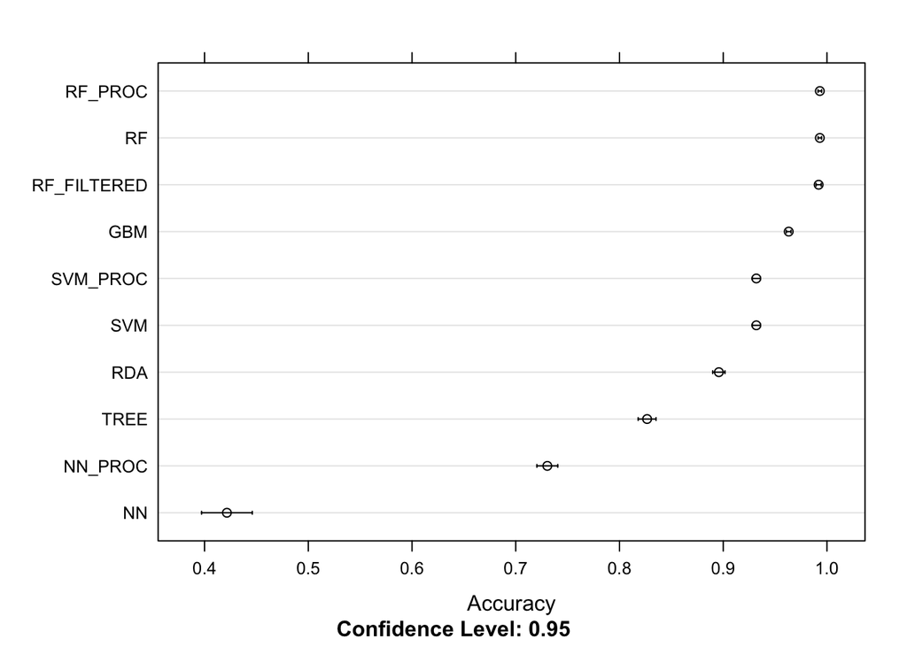

```r
trellis.par.set(caretTheme())
dotplot(resamps, metric = "Accuracy")
```

```r
pred_rf_cleanData <- predict(randomForest_cleanDataFit, newdata=cleanDataVal[,-53])
pred_rf_filteredData <- predict(randomForest_filteredDataFit, newdata=filteredDataVal[,-32])
pred_rf_cleanProcData <- predict(randomForest_cleanProcDataFit, newdata=cleanProcDataVal[,-53])
pred_gbm_cleanData <- predict(gbmFitAll, newdata=cleanDataVal[,-53])
pred_tree_cleanData <- predict(treeFitAll, newdata=cleanDataVal[,-53])
pred_rda_cleanData <- predict(rdaFitAll, newdata=cleanDataVal[,-53])
pred_nnet_cleanData <- predict(nnetFitAll, newdata=cleanDataVal[,-53])
pred_nnet_cleanProcData <- predict(nnetFitAllProc, newdata=cleanProcDataVal[,-53])
pred_svm_cleanData <- predict(svmFitAll, newdata=cleanDataVal[,-53])
pred_svm_cleanProcData <- predict(svmFitAllProc, newdata=cleanProcDataVal[,-53])
```

```r
out_error <- rbind(RF = postResample(pred=pred_rf_cleanData, obs=cleanDataVal$classe),
                   RF_FILTERED = postResample(pred=pred_rf_filteredData, obs=filteredDataVal$classe))
out_error <- rbind(out_error,
                   RF_PROC = postResample(pred=pred_rf_cleanProcData, obs=cleanProcDataVal$classe))
out_error <- rbind(out_error,
                   GBM = postResample(pred=pred_gbm_cleanData, obs=cleanDataVal$classe))
out_error <- rbind(out_error,
                   TREE = postResample(pred=pred_tree_cleanData, obs=cleanDataVal$classe))
out_error <- rbind(out_error,
                   RDA = postResample(pred=pred_rda_cleanData, obs=cleanDataVal$classe))
out_error <- rbind(out_error,
                   NN = postResample(pred=pred_nnet_cleanData, obs=cleanDataVal$classe))
out_error <- rbind(out_error,
                   NN_PROC = postResample(pred=pred_nnet_cleanProcData, obs=cleanProcDataVal$classe))
out_error <- rbind(out_error,
                   SVM = postResample(pred=pred_svm_cleanData, obs=cleanDataVal$classe))
out_error <- rbind(out_error,
                   SVM_PROC = postResample(pred=pred_svm_cleanProcData, obs=cleanProcDataVal$classe))

out_error
```

```
##              Accuracy     Kappa
## RF          0.9956666 0.9945183
## RF_FILTERED 1.0000000 1.0000000
## RF_PROC     1.0000000 1.0000000
## GBM         0.9668621 0.9580735
## TREE        0.8304869 0.7854230
## RDA         0.8949783 0.8672030
## NN          0.4664797 0.3334934
## NN_PROC     0.7438053 0.6749769
## SVM         0.9342340 0.9166686
## SVM_PROC    0.9426715 0.9273569
```

## Final Model

```r
randomForest_cleanProcDataFit
```

```
## Random Forest
##
## 15699 samples
##    52 predictor
##     5 classes: 'A', 'B', 'C', 'D', 'E'
##
## No pre-processing
## Resampling: Cross-Validated (10 fold, repeated 1 times)
## Summary of sample sizes: 14129, 14129, 14128, 14130, 14128, 14129, ...
## Resampling results across tuning parameters:
##
##   mtry  Accuracy   Kappa
##    2    0.9931209  0.9912979
##   27    0.9927391  0.9908148
##   52    0.9858588  0.9821107
##
## Accuracy was used to select the optimal model using  the largest value.
## The final value used for the model was mtry = 2.
```

```r
confusionMatrix.train(randomForest_cleanProcDataFit)
```

```
## Cross-Validated (10 fold, repeated 1 times) Confusion Matrix
##
## (entries are percentual average cell counts across resamples)
##
##           Reference
## Prediction    A    B    C    D    E
##          A 28.4  0.1  0.0  0.0  0.0
##          B  0.0 19.2  0.2  0.0  0.0
##          C  0.0  0.1 17.2  0.3  0.0
##          D  0.0  0.0  0.0 16.1  0.0
##          E  0.0  0.0  0.0  0.0 18.3
##
##  Accuracy (average) : 0.9931
```

```r
confusionMatrix(data=pred_rf_cleanProcData, reference=cleanProcDataVal$classe)
```

```
## Confusion Matrix and Statistics
##
##           Reference
## Prediction    A    B    C    D    E
##          A 4464    0    0    0    0
##          B    0 3038    0    0    0
##          C    0    0 2738    0    0
##          D    0    0    0 2573    0
##          E    0    0    0    0 2886
##
## Overall Statistics
##
##                Accuracy : 1
##                  95% CI : (0.9998, 1)
##     No Information Rate : 0.2843
##     P-Value [Acc > NIR] : < 2.2e-16
##
##                   Kappa : 1
##  Mcnemar's Test P-Value : NA
##
## Statistics by Class:
##
##                      Class: A Class: B Class: C Class: D Class: E
## Sensitivity            1.0000   1.0000   1.0000   1.0000   1.0000
## Specificity            1.0000   1.0000   1.0000   1.0000   1.0000
## Pos Pred Value         1.0000   1.0000   1.0000   1.0000   1.0000
## Neg Pred Value         1.0000   1.0000   1.0000   1.0000   1.0000
## Prevalence             0.2843   0.1935   0.1744   0.1639   0.1838
## Detection Rate         0.2843   0.1935   0.1744   0.1639   0.1838
## Detection Prevalence   0.2843   0.1935   0.1744   0.1639   0.1838
## Balanced Accuracy      1.0000   1.0000   1.0000   1.0000   1.0000
```

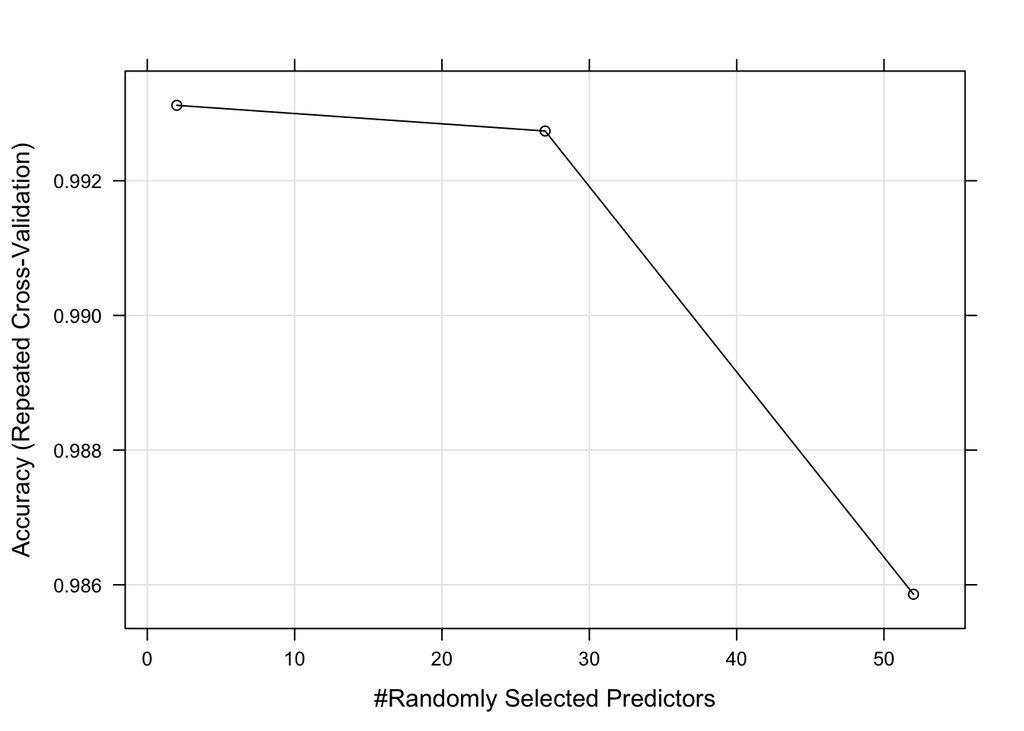

```r
trellis.par.set(caretTheme())
plot(randomForest_cleanProcDataFit)
```

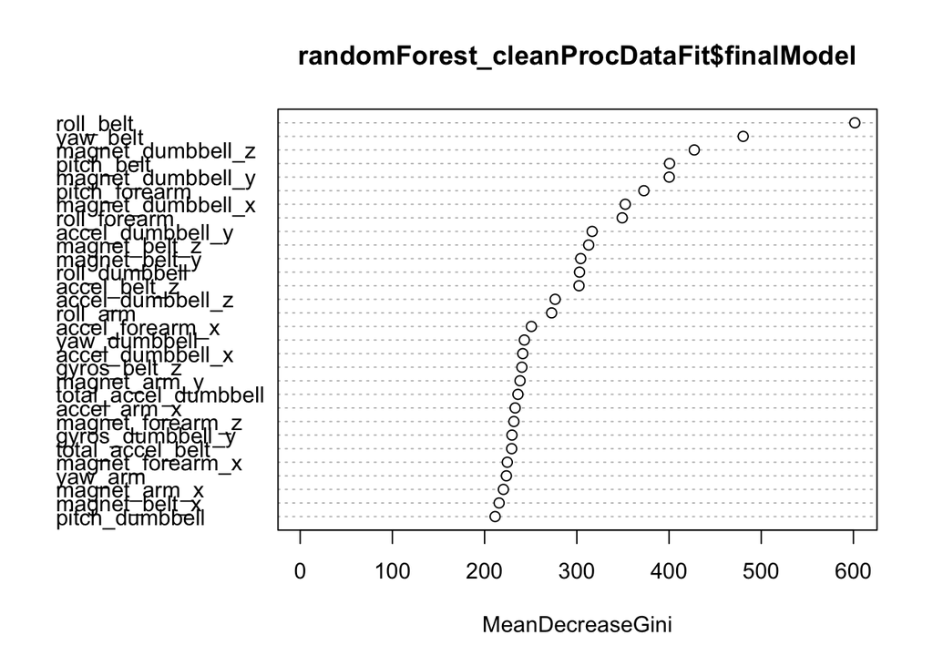

```r
varImpPlot(randomForest_cleanProcDataFit$finalModel,type=2)
```